[Portfolio Home](https://jmerchen.github.io/Jackson_Merchen.github.io/)

# Regression Analysis

Jackson Merchen

## Introduction and Overview

This document provides a knowledge of residuals, the total sum of squares, the sum of squared errors, the sum of squares regression, and R-squared. It also talks about their uses in regression analysis. The actual regression relation between two variables is typically unknown. A regression line provides us with an estimate of the unknown true line using an explanatory variable from collected data. The regression that will be used throughout the document as an example of each is provided below:

#### Used Regression

The regression that we will use is found comparing the RAM of a computer to the Price for that computer.

```r
laptop <- read.csv("/Users/jackmerchen/Statistics-Notebook-master/Data/laptops.csv")

Order <- c("2GB", "4GB", "6GB", "8GB", "12GB", "16GB", "24GB", "32GB", "64GB")
laptop$Ram <- factor(laptop$Ram, levels = Order)
laptop$Ram <- as.character(laptop$Ram)
laptop <- laptop %>%
  separate(col = Ram, into = "Ram", sep = -2)
laptop$Ram <- as.numeric(laptop$Ram)
laptop <- laptop %>%
  filter(Ram < 64)

laplm <- lm(Price_euros ~ Ram, data = laptop)
summary(laplm) %>%
  pander()
```

|  | Estimate | Std. Error | t value | Pr(>\|t\|) |
| --- | --- | --- | --- | --- |
| **(Intercept)** | 226.7 | 25.43 | 8.916 | 1.601e-18 |
| **Ram** | 107.3 | 2.636 | 40.7 | 3.287e-234 |

Fitting linear model: Price_euros ~ Ram

| Observations | Residual Std. Error | $R^2$ | Adjusted $R^2$ |
| --- | --- | --- | --- |
| 1302 | 460.9 | 0.5603 | 0.56 |

##### Estimated Regression Line:

$$\underbrace{\hat{Y}_i}_\text{Price} = \overbrace{b_0}^\text{est.
y-int} + \overbrace{b_1}^\text{est. slope} \underbrace{X_i}_\text{RAM}$$

$$\underbrace{\hat{Y}_i}_\text{Price} = 226.7 + 107.3
\underbrace{X_i}_\text{RAM}$$

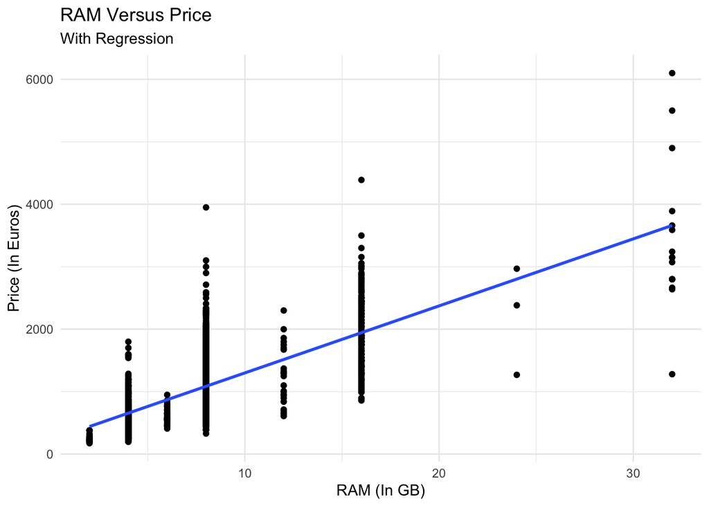

```r
ggplot(data = laptop) +
  geom_point(aes(Ram, Price_euros)) +
  geom_smooth(aes(Ram, Price_euros), method = "lm", se = F) +
  ggtitle("RAM Versus Price",  "With Regression") +
  xlab("RAM (In GB)") +
  ylab("Price (In Euros)") +
  theme_minimal()
```

## Residuals

A residual is the difference between an observed value for Y and the estimated value for Y from our regression. This value is different from an error in that error is the difference between an observed value for Y and the predicted value for Y from the true line. Thus, a residual can be calculated while the error would be unknown. The value of a residual is given by the equation below:

$${r}_i = \overbrace{Y_i}^\text{Observed Y-Value} -
\overbrace{\hat{Y}_i}^\text{Predicted Y-Value}$$

To show this value on the plot, the example regression line will be shown with a new point, given in red. This point represents a computer with RAM of 20GB and a price of 3500. The predicted value for a computer with 20GB RAM would be 2373, giving us a residual of 3500 minus 2373, or 1127. This value is shown be the dashed line in our plot.

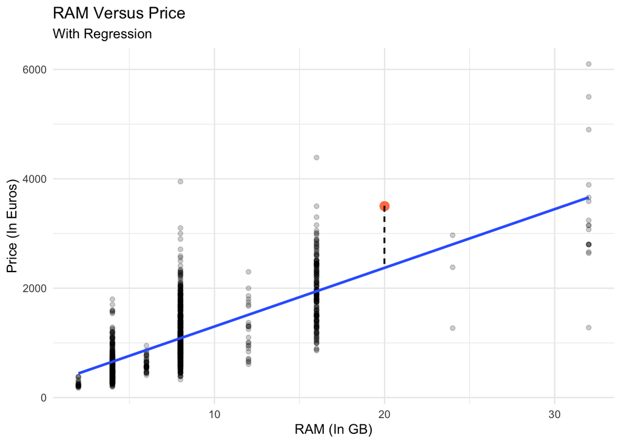

```r
ggplot(data = laptop) +
  geom_point(aes(Ram, Price_euros), alpha = .2) +
  geom_point(aes(x = 20, y = 3500), colour = "coral", size = 3) +
  geom_segment(x = 20, y = 3500, xend = 20, yend = 2373, linetype = "dashed") +
  geom_smooth(aes(Ram, Price_euros), method = "lm", se = F) +
  ggtitle("RAM Versus Price",  "With Regression") +
  xlab("RAM (In GB)") +
  ylab("Price (In Euros)") +
  theme_minimal()
```

The residuals are important in regression analysis for the following reasons:

1. assess the assumptions for regression
2. Estimate the relation for the regression
3. Estimate the Variance of the error terms
4. Assess the fit of the regression relation

## Sum of Squared Errors

The sum of squared errors (SSE) measures how much the residuals deviate from the regression line. This value is given by squaring the difference between an observed y value from the expected y value for the observation, and then summing for each observation, or as given in the equation below:

$$SSE=\sum_{i=1}^{n}(Y_i-\hat{Y}_i)^2$$

This can also be found if SSTO and SSR are known by $SSE=SSTO-SSR$. This value would be the sum of each of the residuals (shown below on the plot) squared. The significance of this value is that it is used in the equations to find both the Total Sum of Squares as well as the correlation.

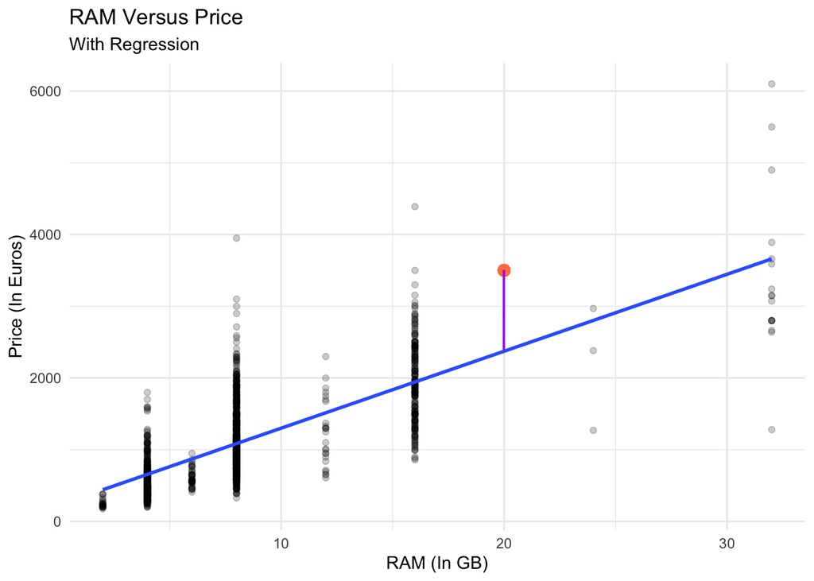

```r
ggplot(data = laptop) +
  geom_point(aes(Ram, Price_euros), alpha = .2) +
  geom_point(aes(x = 20, y = 3500), colour = "coral", size = 3) +
  geom_segment(x = 20, y = 3500, xend = 20, yend = 2373, colour = "darkorchid2") +
  geom_smooth(aes(Ram, Price_euros), method = "lm", se = F) +
  ggtitle("RAM Versus Price",  "With Regression") +
  xlab("RAM (In GB)") +
  ylab("Price (In Euros)") +
  theme_minimal()
```

## Sum of Squares Regression

The sum of squares regression (SSR) is the measure of how much each expected point differs from the mean. This value is found by squaring the difference between the predicted y value for an observation from the average y value and then summing for each observation, or as given below:

$$SSR=\sum_{i=1}^{n}(\hat{Y}_i-\bar{Y})^2$$

The expected value subtracted by the mean is shown in the plot below. The SSR is found by squaring this value and then summing for each expected value in the regression model. Its use in regression analysis is that this value plus the SSE is equal to the Total Sum of Squares, or $SSTO=SSR+SSE$. This value is also used in finding the correlation.

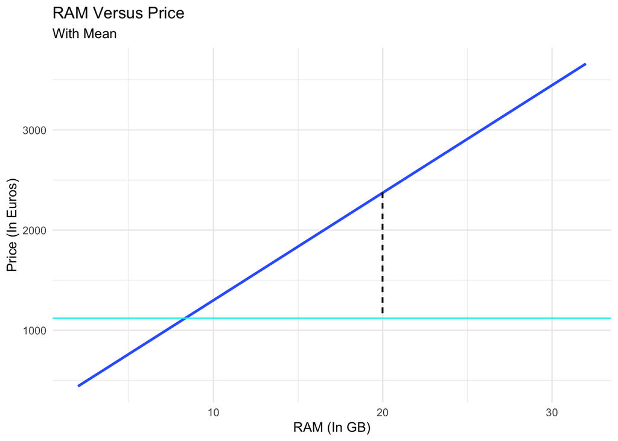

```r
ggplot(data = laptop) +
  geom_smooth(aes(Ram, Price_euros), method = "lm", se = F) +
  geom_segment(x = 20, y = 2373, xend = 20, yend = 1121, linetype = "dashed") +
  geom_hline(yintercept = 1121, colour = "cyan2") +
  ggtitle("RAM Versus Price",  "With Mean") +
  xlab("RAM (In GB)") +
  ylab("Price (In Euros)") +
  theme_minimal()
```

## Total Sum of Squares

The total sum of squares (SSTO) is the measure of how much the observed y values differ from the average y value. This is found by squaring the difference between the observed y value from the average y value and then summing for each observed value, or shown in the equation below:

$$SSTO=\sum_{i=1}^{n}(Y_i-\bar{Y})^2$$

The value of the observed y value minus the average y value is given by the total line from the red point to the mean. The SSTO is found by summing the squares for each of these values for each observation. The SSTO can also be found by $SSTO=SSE+SSR$.

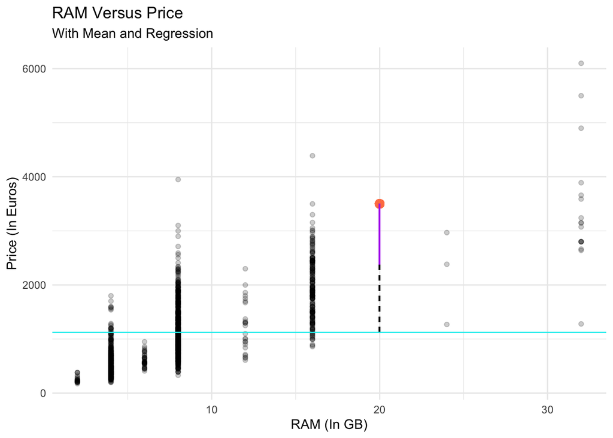

```r
ggplot(data = laptop) +
  geom_point(aes(Ram, Price_euros), alpha = .2) +
  geom_point(aes(x = 20, y = 3500), colour = "coral", size = 3) +
  geom_segment(x = 20, y = 3500, xend = 20, yend = 2373, colour = "darkorchid2") +
  geom_segment(x = 20, y = 2373, xend = 20, yend = 1121, linetype = "dashed") +
  geom_hline(yintercept = 1121, colour = "cyan2") +
  ggtitle("RAM Versus Price",  "With Mean and Regression") +
  xlab("RAM (In GB)") +
  ylab("Price (In Euros)") +
  theme_minimal()
```

This value is used in regression analysis in determining the correlation.

## $R^2$

```r
laptop <- laptop %>%
  separate(col = Weight, into = "Weight", sep = -2)
laptop$Weight <- as.numeric(laptop$Weight)
weightlm <- lm(Price_euros ~ Weight, data = laptop)

summary(laplm) %>%
  pander()
```

|  | Estimate | Std. Error | t value | Pr(>\|t\|) |
| --- | --- | --- | --- | --- |
| **(Intercept)** | 226.7 | 25.43 | 8.916 | 1.601e-18 |
| **Ram** | 107.3 | 2.636 | 40.7 | 3.287e-234 |

Fitting linear model: Price_euros ~ Ram

| Observations | Residual Std. Error | $R^2$ | Adjusted $R^2$ |
| --- | --- | --- | --- |
| 1302 | 460.9 | 0.5603 | 0.56 |

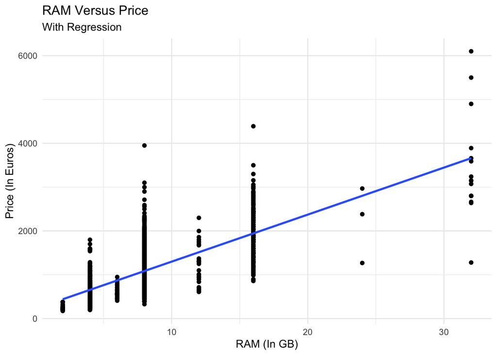

```r
ggplot(data = laptop) +
  geom_point(aes(Ram, Price_euros)) +
  geom_smooth(aes(Ram, Price_euros), method = "lm", se = F) +
  ggtitle("RAM Versus Price",  "With Regression") +
  xlab("RAM (In GB)") +
  ylab("Price (In Euros)") +
  theme_minimal()
```

```r
summary(weightlm) %>%
  pander()
```

|  | Estimate | Std. Error | t value | Pr(>\|t\|) |
| --- | --- | --- | --- | --- |
| **(Intercept)** | 685 | 60.84 | 11.26 | 4.008e-28 |
| **Weight** | 214.2 | 28.39 | 7.546 | 8.422e-14 |

Fitting linear model: Price_euros ~ Weight

| Observations | Residual Std. Error | $R^2$ | Adjusted $R^2$ |
| --- | --- | --- | --- |
| 1302 | 680.3 | 0.04196 | 0.04122 |

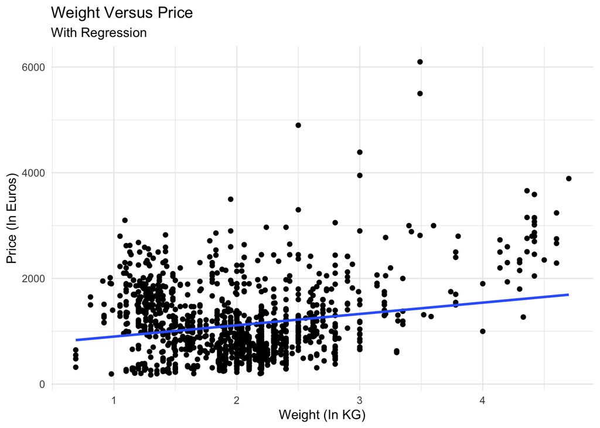

```r
ggplot(data = laptop) +
  geom_point(aes(Weight, Price_euros)) +
  geom_smooth(aes(Weight, Price_euros), method = "lm", se = F) +
  ggtitle("Weight Versus Price",  "With Regression") +
  xlab("Weight (In KG)") +
  ylab("Price (In Euros)") +
  theme_minimal()
```